# nero_spacy

```python
!pip install plac
!pip install spacy
!pip install spacy_lookups_data
```

```python
!python -m spacy download en_core_web_sm
```

```python
from __future__ import unicode_literals, print_function

import plac
import random
import warnings
from pathlib import Path
import spacy
from spacy.util import minibatch, compounding
```

```python
from spacy import displacy
```

```python
import numpy as np
import pandas as pd
```

```python
import matplotlib.pyplot as plt
```

```python
import time
```

```python
import warnings
warnings.filterwarnings('ignore')
```

```python
import re
```

```python
import json
```

## This notebook contains:

### spaCy Documentation references

- https://spacy.io/usage/training
- https://spacy.io/usage/linguistic-features#named-entities

### NERsuite (http://nersuite.nlplab.org/)

- ran into installation (dependancy) issues for the NERsuite package
- specifically, had some issues installing the forked version of crfsuite (one of the dependancies)

See Github issues requests below:

- https://github.com/nlplab/nersuite/issues/26
- https://github.com/nlplab/nersuite/issues/23

#### A toy working example of spaCy NER

```python
texts = [
    "Net income was $9.4 million compared to the prior year of $2.7 million.",
    "Revenue exceeded twelve billion dollars, with a loss of $1b.",
]

nlp_test = spacy.load("en_core_web_sm")  # loading the default english language model

# disbale tagger and parser from the pipeline if we're only using named entity recognizer
for doc in nlp_test.pipe(texts, disable=["tagger", "parser"]):
    print([(ent.text, ent.label_) for ent in doc.ents])
    displacy.render(doc, style="ent")
```

```
[('$9.4 million', 'MONEY'), ('the prior year', 'DATE'), ('$2.7 million', 'MONEY')]
```

Net income was $9.4 million MONEY compared to the prior year DATE of $2.7 million MONEY .

```
[('twelve billion dollars', 'MONEY'), ('1b', 'MONEY')]
```

Revenue exceeded twelve billion dollars MONEY , with a loss of $ 1b MONEY .

### Our unannotated corpus:

```python
f = open("sentence_list.txt")
corpus = f.read()
corpus_ls = corpus.split('\n')
corpus_ls[:5]
```

```
['( A) Amph2 SH3 and Amph2-SH3deltaDAPS domains bind equally well to dynamin.',
 '( A) and an NH -terminal deletion mutant  Bcl-2( 1-82) retained Bax binding activity  in vitro  but failed to suppress Bax-mediated cytotoxicity in yeast.',
 '( A) and cephalexin ( B) binding to WT BcII (filled circles) and M5 (open circles).',
 '( A) and competitive binding of V2R-pp and V2R-np to beta-arrestin_2 ( B).',
 '( A) and irreversible ( B) binding of PAC-1  to thrombin-stimulated platelets.']
```

```python
f.close()
```

#### Try applying the default pretrained NER model on our unannotated corpus (first 3 sentences)

#### we notice that the assigned entity classes are meaningless (our desired entity classes are not present in the pretrained model).

```python
for doc in nlp_test.pipe(corpus_ls[:3], disable=["tagger", "parser"]):
    print([(ent.text, ent.label_) for ent in doc.ents])
    displacy.render(doc, style="ent")
```

```
[('Amph2-SH3deltaDAPS', 'GPE')]
```

( A) Amph2 SH3 and Amph2-SH3deltaDAPS GPE domains bind equally well to dynamin.

```
[('NH', 'ORG'), ('Bax', 'PRODUCT'), ('Bax', 'ORG')]
```

( A) and an NH ORG -terminal deletion mutant Bcl-2( 1-82) retained Bax PRODUCT binding activity in vitro but failed to suppress Bax ORG -mediated cytotoxicity in yeast.

```
[('WT BcII', 'ORG')]
```

( A) and cephalexin ( B) binding to WT BcII ORG (filled circles) and M5 (open circles).

### Exploring the annotated files we have

- Each line in the file below contains a token and entity class (ENT1, ENT2, ACT). Semantic classes (disease, gene/protein, etc.) are not known here.
- One way to create traning data is to generate a token-label mapping from the file with full annotation results
- Alternatively, we could directly create training data using the file with full annotation results (details below)

```python
df1 = pd.read_table('annotation_conll_format.txt', header=None)
print(df1[60:70])
```

```
                      0
60                 SH3
61                 and
62  Amph2-SH3deltaDAPS
63             domains
64           bind B-ACT
65             equally
66                well
67                  to
68       dynamin B-ENT2
69                   .
```

```python
df2 = pd.read_table('annotation_results_clean.txt')
df2.head(5)
```

|  | sdocId | userId | amId | assignedId | entity1 | actionType | entity2 | sentenceText | Unnamed: 8 |
| --- | --- | --- | --- | --- | --- | --- | --- | --- | --- |
| 0 | 12 | 6 | 44403 | 2 | asd | asd | asd | `Microsomal` membrane prepared as described fr... | NaN |
| 1 | 12 | 7 | 1040 | 3 | testing | action test | dfgf | `Microsomal` membrane prepared as described fr... | NaN |
| 2 | 201 | 5 | 57771 | 1 | Amph2 | bind | dynamin | ( A) Amph2 SH3 and Amph2-SH3deltaDAPS domains ... | NaN |
| 3 | 201 | 5 | 57772 | 2 | Amph2 | bind | dynamin | ( A) Amph2 SH3 and Amph2-SH3deltaDAPS domains ... | NaN |
| 4 | 201 | 6 | 1108 | 1 | Amph2 | bind | dynamin | ( A) Amph2 SH3 and Amph2-SH3deltaDAPS domains ... | NaN |

```python
# few missing values but lack semantic labels
df2.isnull().sum()
```

```
sdocId              0
userId              0
amId                0
assignedId          0
entity1             5
actionType          2
entity2             5
sentenceText        0
Unnamed: 8      68447
dtype: int64
```

### reading into pandas the complete annotation results

- we observe below that each sentence occupied multiple rows due to results from different annotators
- we'll use info from columns (entity1, semantic_class_entity1, entity2, semantic_class_entity2, sentences) to create training data for spaCy

```python
# Initially had some trouble reading the data into pandas, changing the encoding from utf-8 to latin1 fixed the error

df3 = pd.read_table("annotation_results_all_jan2016.txt", header=0, encoding='latin1')
df3.head(10)
```

|  | amId | assignedId | sdocId | userId | editorUserId | indexActionMentionId | external_id | dbActionMentionId | entity1 | semantic_class_entity1 | ... | topic | statement_context | negative | certainty_level | derived_certainty_level | applied_rule | indexSentenceId | pmid | sentenceText | procset |
| --- | --- | --- | --- | --- | --- | --- | --- | --- | --- | --- | --- | --- | --- | --- | --- | --- | --- | --- | --- | --- | --- |
| 0 | 44403 | 2 | 12.0 | 6 | 10.0 | NaN | 0.0 | NaN | asd | NaN | ... | NaN | NaN | 0.0 | NaN | NaN | NaN | gw60_biochmbiophyrescomm_295_4_1027_s_40 | 12127999.0 | `Microsomal` membrane prepared as described fr... | bind |
| 1 | 1040 | 3 | 12.0 | 7 | 10.0 | NaN | 0.0 | NaN | testing | NaN | ... | NaN | NaN | NaN | NaN | NaN | NaN | gw60_biochmbiophyrescomm_295_4_1027_s_40 | 12127999.0 | `Microsomal` membrane prepared as described fr... | bind |
| 2 | 57771 | 1 | 201.0 | 5 | NaN | NaN | 0.0 | NaN | Amph2 | GP | ... | NaN | NaN | 0.0 | NaN | NaN | NaN | gw60_embo_17_18_5273_s_218 | 9736607.0 | ( A) Amph2 SH3 and Amph2-SH3deltaDAPS domains ... | bind |
| 3 | 57772 | 2 | 201.0 | 5 | NaN | NaN | 0.0 | NaN | Amph2 | GP | ... | NaN | NaN | 0.0 | NaN | NaN | NaN | gw60_embo_17_18_5273_s_218 | 9736607.0 | ( A) Amph2 SH3 and Amph2-SH3deltaDAPS domains ... | bind |
| 4 | 1108 | 1 | 201.0 | 6 | NaN | NaN | 0.0 | NaN | Amph2 | GP | ... | NaN | NaN | NaN | NaN | NaN | NaN | gw60_embo_17_18_5273_s_218 | 9736607.0 | ( A) Amph2 SH3 and Amph2-SH3deltaDAPS domains ... | bind |
| 5 | 1109 | 2 | 201.0 | 6 | NaN | NaN | 0.0 | NaN | Amph2 | GP | ... | NaN | NaN | NaN | NaN | NaN | NaN | gw60_embo_17_18_5273_s_218 | 9736607.0 | ( A) Amph2 SH3 and Amph2-SH3deltaDAPS domains ... | bind |
| 6 | 57773 | 1 | 212.0 | 5 | NaN | NaN | 0.0 | NaN | Bcl-2 | GP | ... | NaN | in vitro | NaN | NaN | NaN | NaN | gw60_jbiolchem_270_20_11962_s_8 | 7744846.0 | ( A) and an NH -terminal deletion mutant Bcl-... | bind |
| 7 | 57774 | 2 | 212.0 | 5 | NaN | NaN | 0.0 | NaN | Bax | GP | ... | NaN | yeast | NaN | NaN | NaN | NaN | gw60_jbiolchem_270_20_11962_s_8 | 7744846.0 | ( A) and an NH -terminal deletion mutant Bcl-... | bind |
| 8 | 57775 | 3 | 212.0 | 5 | NaN | NaN | 0.0 | NaN | Bcl-2 | GP | ... | NaN | yeast | NaN | NaN | NaN | NaN | gw60_jbiolchem_270_20_11962_s_8 | 7744846.0 | ( A) and an NH -terminal deletion mutant Bcl-... | bind |
| 9 | 1110 | 1 | 212.0 | 6 | NaN | NaN | 0.0 | NaN | Bcl-2 | GP | ... | NaN | In vitro | NaN | NaN | NaN | NaN | gw60_jbiolchem_270_20_11962_s_8 | 7744846.0 | ( A) and an NH -terminal deletion mutant Bcl-... | bind |

10 rows × 31 columns

```python
# missing percent per variable; the variable with highest missing rate on top
df3.isnull().mean().sort_values(ascending=False)
```

```
topic                        1.000000
applied_rule                 1.000000
derived_certainty_level      1.000000
certainty_level              1.000000
dbActionMentionId            0.999997
indexActionMentionId         0.999997
semantic_class_actionType    0.999986
gene_region_entity1          0.997800
gene_region_entity2          0.988984
protein_domain_entity1       0.987104
protein_domain_entity2       0.987013
statement_context            0.981811
modifier_actionType          0.981011
modifier_entity1             0.968526
modifier_entity2             0.955759
editorUserId                 0.912306
semantic_class_entity2       0.868677
pmid                         0.816833
indexSentenceId              0.816535
entity2                      0.808122
procset                      0.800480
actionType                   0.800477
negative                     0.557975
external_id                  0.520651
semantic_class_entity1       0.465336
entity1                      0.403964
sentenceText                 0.400248
sdocId                       0.400240
userId                       0.400237
amId                         0.400232
assignedId                   0.000008
dtype: float64
```

```python
#df3.dtypes
```

```python
#top 20 entity classes for entity1 by counts (duplicates included)
df3.semantic_class_entity1.value_counts()[:20]
```

```
GP                       26842
Process                  23796
MedicalFinding           15867
Chemical                 12886
BiologicalProcess         8059
MolecularProcess          7725
Protein                   7338
Quantity                  7031
ResearchActivity          6554
MedicalProcedure          6336
Organism                  6259
Measurement               5238
PersonGroup               5225
BodyPart                  4969
Cell                      4543
Disease                   3940
NamedEntity               3607
NucleicAcid               3245
QuantityOrMeasurement     2851
Drug                      2516
Name: semantic_class_entity1, dtype: int64
```

```python
#top 20 entity classes for entity2 by counts (duplicates included)
df3.semantic_class_entity2.value_counts()[:20]
```

```
GP                                 22587
Process                            10754
Chemical                            4323
NucleicAcid                         2114
MedicalFinding                      1846
Cell                                1178
CellComponent                       1109
Protein                              580
OrganismPart                         441
Organism                             411
AminoAcid                            324
Chromosome                           287
NucleicAcidSubstance                 176
GroupOfPeople                        169
GeneOrProtein                        144
NonProteinOrNucleicAcidChemical      140
Disease                              119
MedicalProcedure                      96
PhysicalPhenomenon                    94
BodyPart                              82
Name: semantic_class_entity2, dtype: int64
```

```python
# top 20 action terms
df3.actionType.value_counts()[:20]
```

```
bind                    20500
is a type of             3578
is                       2437
does not bind            1471
binds                    1088
inhibits                 1024
induce                   1010
leads to                  992
activates                 840
inhibit                   826
binds to                  740
is an alternative to      709
interacts with            604
contains                  576
binds to                  545
is required for           534
induces                   526
mediates                  513
is dependent on           440
regulates                 411
Name: actionType, dtype: int64
```

```
Text(0,0.5,'count')
```

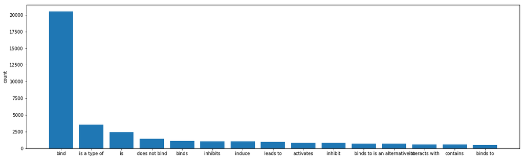

```python
# frequency bar plot for the top 15 action terms
action = df3.actionType.value_counts()[:15]
plt.figure(figsize=(20, 6))
plt.bar(action.index, action.values)
plt.ylabel('count')
```

```
Text(0,0.5,'log count')
```

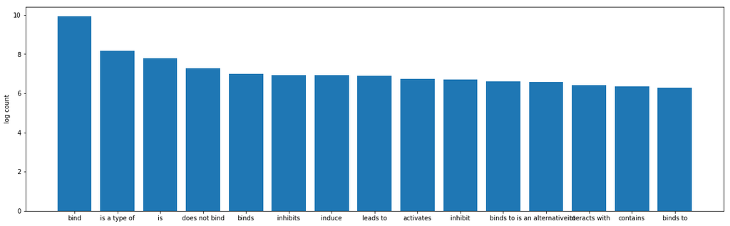

```python
# frequency bar plot for the top 15 action terms
# log(count)
action = df3.actionType.value_counts()[:15]
plt.figure(figsize=(20, 6))
plt.bar(action.index, np.log(action.values))
plt.ylabel('log count')
```

```python
# removing the first two sentences
df3 = df3[2:]
df3.reset_index(drop=True, inplace=True)
df3.head(5)
```

|  | amId | assignedId | sdocId | userId | editorUserId | indexActionMentionId | external_id | dbActionMentionId | entity1 | semantic_class_entity1 | ... | topic | statement_context | negative | certainty_level | derived_certainty_level | applied_rule | indexSentenceId | pmid | sentenceText | procset |
| --- | --- | --- | --- | --- | --- | --- | --- | --- | --- | --- | --- | --- | --- | --- | --- | --- | --- | --- | --- | --- | --- |
| 0 | 57771 | 1 | 201.0 | 5 | NaN | NaN | 0.0 | NaN | Amph2 | GP | ... | NaN | NaN | 0.0 | NaN | NaN | NaN | gw60_embo_17_18_5273_s_218 | 9736607.0 | ( A) Amph2 SH3 and Amph2-SH3deltaDAPS domains ... | bind |
| 1 | 57772 | 2 | 201.0 | 5 | NaN | NaN | 0.0 | NaN | Amph2 | GP | ... | NaN | NaN | 0.0 | NaN | NaN | NaN | gw60_embo_17_18_5273_s_218 | 9736607.0 | ( A) Amph2 SH3 and Amph2-SH3deltaDAPS domains ... | bind |
| 2 | 1108 | 1 | 201.0 | 6 | NaN | NaN | 0.0 | NaN | Amph2 | GP | ... | NaN | NaN | NaN | NaN | NaN | NaN | gw60_embo_17_18_5273_s_218 | 9736607.0 | ( A) Amph2 SH3 and Amph2-SH3deltaDAPS domains ... | bind |
| 3 | 1109 | 2 | 201.0 | 6 | NaN | NaN | 0.0 | NaN | Amph2 | GP | ... | NaN | NaN | NaN | NaN | NaN | NaN | gw60_embo_17_18_5273_s_218 | 9736607.0 | ( A) Amph2 SH3 and Amph2-SH3deltaDAPS domains ... | bind |
| 4 | 57773 | 1 | 212.0 | 5 | NaN | NaN | 0.0 | NaN | Bcl-2 | GP | ... | NaN | in vitro | NaN | NaN | NaN | NaN | gw60_jbiolchem_270_20_11962_s_8 | 7744846.0 | ( A) and an NH -terminal deletion mutant Bcl-... | bind |

5 rows × 31 columns

```python
df3.shape
```

```
(362738, 31)
```

### Below we create training data ready for spaCy

- the idea is that for each sentence in the corpus, use str.index() to find character offsets for a token in the sentence

```python
sent_ls = df3.sentenceText

ent1_ls = df3.entity1
ent2_ls = df3.entity2

ent1_label = df3.semantic_class_entity1
ent2_label = df3.semantic_class_entity2

dict_ls = [] # a empty list for storing dictionaries; each dictionary contains character offsets and labels for a sentence
ix = [] # list of indices for sentences with at least one label
```

```python
time_start = time.time()


for i in range(len(df3)):

    ent_ls = [] # list of entity tuples

    if (isinstance(ent1_ls[i], str) == True) and (isinstance(ent1_label[i], str) == True):
        try:
            start1, end1, label1 = sent_ls[i].index(ent1_ls[i]), sent_ls[i].index(ent1_ls[i]) + len(ent1_ls[i]), ent1_label[i]
            ent_ls.append((start1, end1, label1))
        except:
            pass


    if (isinstance(ent2_ls[i], str) == True) and (isinstance(ent2_label[i], str) == True):
        try:
            start2, end2, label2 = sent_ls[i].index(ent2_ls[i]), sent_ls[i].index(ent2_ls[i]) + len(ent2_ls[i]), ent2_label[i]
            ent_ls.append((start2, end2, label2))
        except:
            pass

    if len(ent_ls) == 2:
        if start2 < end1:   # if indices for two entities overlap, keep the indices for the first entity
            ent_ls = [ent_ls[0]]

    if ent_ls: # if ent_ls is not empty
        dict_ls.append({"entities": ent_ls})
        ix.append(i)


print('Time elapsed: {} seconds'.format(time.time()-time_start))
```

```
Time elapsed: 26.92623805999756 seconds
```

```python
dict_ls[:10]
```

```
[{'entities': [(5, 10, 'GP'), (67, 74, 'GP')]},
 {'entities': [(5, 10, 'GP'), (67, 74, 'GP')]},
 {'entities': [(5, 10, 'GP'), (67, 74, 'GP')]},
 {'entities': [(5, 10, 'GP'), (67, 74, 'GP')]},
 {'entities': [(42, 47, 'GP'), (64, 67, 'GP')]},
 {'entities': [(64, 67, 'GP'), (132, 144, 'Process')]},
 {'entities': [(42, 47, 'GP')]},
 {'entities': [(42, 47, 'GP'), (64, 67, 'GP')]},
 {'entities': [(42, 47, 'GP')]},
 {'entities': [(64, 67, 'GP'), (132, 144, 'Process')]}]
```

```python
len(dict_ls) # number of sentences with at least one label
```

```
185364
```

```python
len(df3.sentenceText[ix])
```

```
185364
```

```python
# below is the desired format for training
our_train_data = list(zip(list(df3.sentenceText[ix]), dict_ls))
our_train_data[:5]
```

```
[('( A) Amph2 SH3 and Amph2-SH3deltaDAPS domains bind equally well to dynamin.',
  {'entities': [(5, 10, 'GP'), (67, 74, 'GP')]}),
 ('( A) Amph2 SH3 and Amph2-SH3deltaDAPS domains bind equally well to dynamin.',
  {'entities': [(5, 10, 'GP'), (67, 74, 'GP')]}),
 ('( A) Amph2 SH3 and Amph2-SH3deltaDAPS domains bind equally well to dynamin.',
  {'entities': [(5, 10, 'GP'), (67, 74, 'GP')]}),
 ('( A) Amph2 SH3 and Amph2-SH3deltaDAPS domains bind equally well to dynamin.',
  {'entities': [(5, 10, 'GP'), (67, 74, 'GP')]}),
 ('( A) and an NH -terminal deletion mutant  Bcl-2( 1-82) retained Bax binding activity  in vitro  but failed to suppress Bax-mediated cytotoxicity in yeast.',
  {'entities': [(42, 47, 'GP'), (64, 67, 'GP')]})]
```

#### initial training resulted in an error: "Could not find an optimal move to supervise the parser"

- the script below resolved the issue

```python
# the function below Removes leading and trailing white spaces from entity spans
# https://github.com/explosion/spaCy/issues/3558#issuecomment-487953653

def trim_entity_spans(data: list) -> list:
    """Removes leading and trailing white spaces from entity spans.

    Args:
        data (list): The data to be cleaned in spaCy JSON format.

    Returns:
        list: The cleaned data.
    """
    invalid_span_tokens = re.compile(r'\s')

    cleaned_data = []
    for text, annotations in data:
        entities = annotations['entities']
        valid_entities = []
        for start, end, label in entities:
            valid_start = start
            valid_end = end
            while valid_start < len(text) and invalid_span_tokens.match(
                    text[valid_start]):
                valid_start += 1
            while valid_end > 1 and invalid_span_tokens.match(
                    text[valid_end - 1]):
                valid_end -= 1
            valid_entities.append([valid_start, valid_end, label])
        cleaned_data.append([text, {'entities': valid_entities}])

    return cleaned_data
```

```python
# cleaning our train data

train_data_cleaned = trim_entity_spans(our_train_data)
train_data_cleaned[:5]
```

```
[['( A) Amph2 SH3 and Amph2-SH3deltaDAPS domains bind equally well to dynamin.',
  {'entities': [[5, 10, 'GP'], [67, 74, 'GP']]}],
 ['( A) Amph2 SH3 and Amph2-SH3deltaDAPS domains bind equally well to dynamin.',
  {'entities': [[5, 10, 'GP'], [67, 74, 'GP']]}],
 ['( A) Amph2 SH3 and Amph2-SH3deltaDAPS domains bind equally well to dynamin.',
  {'entities': [[5, 10, 'GP'], [67, 74, 'GP']]}],
 ['( A) Amph2 SH3 and Amph2-SH3deltaDAPS domains bind equally well to dynamin.',
  {'entities': [[5, 10, 'GP'], [67, 74, 'GP']]}],
 ['( A) and an NH -terminal deletion mutant  Bcl-2( 1-82) retained Bax binding activity  in vitro  but failed to suppress Bax-mediated cytotoxicity in yeast.',
  {'entities': [[42, 47, 'GP'], [64, 67, 'GP']]}]]
```

### We first sample a subset (~10%) of our data to fit the spaCy model (since the training time is more than 24 hours for the whole dataset)

```python
random.seed(10)
subset_index = random.sample(range(len(train_data_cleaned)), int(0.1*len(train_data_cleaned)))
```

```python
len(subset_index)
```

```
18536
```

```python
annotation_subset = [train_data_cleaned[i] for i in subset_index]
annotation_subset[:5]
```

```
[['Most of the active compounds did not show cytotoxic activity against human cancer cell lines and no one possessed hemolytic activity , indicating that their activity is selective to pathogenic fungi and that they are not toxic at MIC concentrations .',
  {'entities': [[182, 198, 'Organism']]}],
 ['(A)-binding protein was identified as a  Xenopus-specific protein that binds AU-rich sequences ( ).',
  {'entities': [[41, 65, 'GP']]}],
 ['The first three cases include a schwannoma , a neurofibroma , and a desmoid tumor of the brachial plexus region .',
  {'entities': [[32, 42, 'MedicalFinding']]}],
 ['The significance of the predominance of phase I introns , the almost uniformly short length of the 42 introns and the overall small size of the gene , is discussed in relation to the evolution of multifunctional proteins .',
  {'entities': [[99, 109, 'NucleicAcid']]}],
 ['Fly mortality increased rapidly after 2 h of anoxia and & gt ; 16 h exposure was uniformly lethal .',
  {'entities': [[0, 13, 'MedicalFinding']]}]]
```

### We then sample 90% of the subset for training, with the remaining 10% for evaluation

```python
random.seed(11)
train_index = random.sample(range(len(annotation_subset)), int(0.9*len(annotation_subset)))
train_data_sub = [annotation_subset[i] for i in train_index]
train_data_sub[:5]
```

```
[['This article provides an overview of the technique of magnetic resonance venography ( MRV ) and its relative value in the diagnostic work-up of suspected lower or upper extremity venous thrombosis .',
  {'entities': [[5, 12, 'PublishedSourceOfInformation']]}],
 ['The onset of tissue damage and increases in vascular permeability in the gastrointestinal tract correlate temporally with the changes in PAF-acether synthesis and have previously been shown to be inhibited by PAF-acether antagonists .',
  {'entities': [[137, 158, 'MolecularProcess']]}],
 ['Sequence analysis of cloned PCR-amplified narG , napA , and nrfA gene sequences showed the indigenous nitrate-reducing communities to be both phylogenetically diverse and also divergent from previously characterized nitrate reduction sequences in soils and offshore marine sediments and from cultu…
  {'entities': [[216, 243, 'NucleicAcid']]}],
 ['The present study investigated the effects of a preparation of a gamma-tocopherol-rich mixture of tocopherols ( gamma-TmT ) on chemically induced lung tumorigenesis in female A/J mice and the growth of H1299 human lung cancer cell xenograft tumors .',
  {'entities': [[35, 42, 'Process']]}],
 ['We studied the mucosa close to the carcinoma of large bowel ( CLB ) in 200 cases , the carcinoma tissue of CLB in 130 and the mucosa of fetus large bowel in 24 by mucin histochemistry , in addition to the mucosa near CLB studied by scanning electron microscope ( SEM ) in 25 .',
  {'entities': [[157, 159, 'Quantity']]}]]
```

```python
test_index = list(set(range(len(annotation_subset))) - set(train_index))
```

```python
len(test_index)
```

```
1854
```

```python
test_data_sub = [annotation_subset[i] for i in test_index]
len(test_data_sub)
```

```
1854
```

### Eventually, we'll want to train a spaCy NER model on the full data, since good performance of NER often requires a large amount of well-annotated data

- we prepare the training set and test set of the full data as below

```python
# sample 90% of the full data to train
random.seed(20)
train_index_full = random.sample(range(len(train_data_cleaned)), int(0.9*len(train_data_cleaned)))
```

```python
len(train_index_full)
```

```
166827
```

```python
train_data_full = [train_data_cleaned[i] for i in train_index_full]
train_data_full[:5]
```

```
[["( Nutritional and neuropsychiatric studies in chronic iodine deficient girls ( author 's transl ) ) .",
  {'entities': [[18, 42, 'ResearchActivity']]}],
 ['We studied the correlation between expression of vascular endothelial growth factor (VEGF), basic fibroblast growth factor (bFGF), and their receptors with vascularity, metastasis, and proliferative index of human colon cancers.Expression of VEGF and KDR was higher in metastatic than in nonmetast…
  {'entities': [[519, 535, 'MedicalFinding'], [545, 565, 'MedicalFinding']]}],
 ['It was shown that the conversion of PC was nearly 100 % , and the yield of bisphenol A ( BPA ) was over 95 % under the following conditions : m ( ( Bmim ) ( Ac ) ) : m ( PC ) = 0.75 : 1 ; m ( methanol ) : m ( PC ) = 0.75 : 1 ; a reaction temperature of 90 C and a total time of 2.5 h. The ionic li…
  {'entities': [[129, 139, 'ExperimentalFactor']]}],
 ['( Lung changes in recurrent tuberculosis of the eye in patients receiving antibacterial preparations ) .',
  {'entities': [[48, 51, 'BodyPart']]}],
 ['Synthetic TRH elicited a constant , prompt increase in PRL levels .',
  {'entities': [[55, 65, 'Quantity']]}]]
```

```python
test_index_full = list(set(range(len(train_data_cleaned))) - set(train_index_full))
```

```python
len(test_index_full)
```

```
18537
```

```python
test_data_full = [train_data_cleaned[i] for i in test_index_full]
len(test_data_full)
```

```
18537
```

### Our desired format for training

```python
# training data format
# TRAIN_DATA = [
#     ("Who is Shaka Khan?", {"entities": [(7, 17, "PERSON")]}),
#     ("I like London and Berlin.", {"entities": [(7, 13, "LOC"), (18, 24, "LOC")]}),
# ]
```

#### We have structured our annotated corpus into the above format

Note: during the initial phase of training, we see a larger number of user warnings: Some entities could not be aligned in the text "(i) GTP-bound eRF3 associates with eRF1 and brings..." with entities "[[117, 142, 'GP'], [158, 166, 'CellComponent']]". Use `spacy.gold.biluo_tags_from_offsets(nlp.make_doc(text), entities)` to check the alignment. Misaligned entities ('-') will be ignored during training.

- https://github.com/explosion/spaCy/issues/5727

#### we dive into one of the sentences that's causing the error below

```python
# locating the sentence in our corpus
for sent in train_data_sub:
    if sent[0].startswith('(i) GTP-bound eRF3 associates with eRF1 and brings'):
        print("Sentence: %s, Entity: %s" % (sent[0], sent[1]))
```

```
Sentence: (i) GTP-bound eRF3 associates with eRF1 and brings it to the ribosomal A site, (ii) the association of eRF3 with the GTPase-activating proteins consisting of ribosome and eRF1 leads to the activation of GTP hydrolysis, and (iii) the resulting GDP-bound form of eRF3 dissociates from eRF1, a…
```

```python
error_txt = '(i) GTP-bound eRF3 associates with eRF1 and brings it to the ribosomal A site, (ii) the association of eRF3 with the GTPase-activating proteins consisting of ribosome and eRF1 leads to the activation of GTP hydrolysis, and (iii) the resulting GDP-bound form of eRF3 dissociates from eRF1, although its lifetime may be quite short in the presence of Mg2+.'
gold_entities = [[117, 142, 'GP'], [158, 166, 'CellComponent']]

# biluo_tags_from_offsets: Encode labelled spans into per-token tags
print(spacy.gold.biluo_tags_from_offsets(nlp_test.make_doc(error_txt), gold_entities))
```

```
['O', 'O', 'O', 'O', 'O', 'O', 'O', 'O', 'O', 'O', 'O', 'O', 'O', 'O', 'O', 'O', 'O', 'O', 'O', 'O', 'O', 'O', 'O', 'O', 'O', 'O', 'O', 'O', '-', '-', '-', '-', 'O', 'O', 'U-CellComponent', 'O', 'O', 'O', 'O', 'O', 'O', 'O', 'O', 'O', 'O', 'O', 'O', 'O', 'O', 'O', 'O', 'O', 'O', 'O', 'O', 'O', 'O', …
```

- we notice 'GP' is not in the above tag list, instead it was replaced by '-'s, indicating misaligned entities, which are ignored during training
- the cause for the missing tag is that in our annotations table, entities can be singular or plural form depending on the annotator, which would lead to the conflict in character offsets
- in general, conflicts arise when the users' annotation tokenization doesn't line up with spacy's tokenization
- takeaway: better pre-processing (lemmatization) on input texts to ensure proper punctuation & white spaces, etc.

```python
error_txt[117:142]
```

```
'GTPase-activating protein'
```

```python
error_txt[117:143]
```

```
'GTPase-activating proteins'
```

### Below is the training script for spaCy's named entity recognizer

```python
# https://github.com/explosion/spaCy/blob/master/examples/training/train_ner.py

TRAIN_DATA = train_data_full


def main(model=None, output_dir=None, n_iter=100):
    """Load the model, set up the pipeline and train the entity recognizer."""
    if model is not None:
        nlp = spacy.load(model)  # load existing spaCy model
        print("Loaded model '%s'" % model)
    else:
        nlp = spacy.blank("en")  # create blank Language class
        print("Created blank 'en' model")

    # create the built-in pipeline components and add them to the pipeline
    # nlp.create_pipe works for built-ins that are registered with spaCy
    if "ner" not in nlp.pipe_names:
        ner = nlp.create_pipe("ner")
        nlp.add_pipe(ner, last=True)
    # otherwise, get it so we can add labels
    else:
        ner = nlp.get_pipe("ner")

    # add labels
    for _, annotations in TRAIN_DATA:
        for ent in annotations.get("entities"):
            ner.add_label(ent[2])

    # get names of other pipes to disable them during training
    pipe_exceptions = ["ner", "trf_wordpiecer", "trf_tok2vec"]
    other_pipes = [pipe for pipe in nlp.pipe_names if pipe not in pipe_exceptions]
    # only train NER
    with nlp.disable_pipes(*other_pipes), warnings.catch_warnings():
        # show warnings for misaligned entity spans once
        warnings.filterwarnings("once", category=UserWarning, module='spacy')

        # reset and initialize the weights randomly – but only if we're
        # training a new model
        if model is None:
            nlp.begin_training()
        for itn in range(n_iter):
            random.shuffle(TRAIN_DATA)
            losses = {}
            # batch up the examples using spaCy's minibatch
            batches = minibatch(TRAIN_DATA, size=compounding(4.0, 32.0, 1.001))
            for batch in batches:
                texts, annotations = zip(*batch)
                nlp.update(
                    texts,  # batch of texts
                    annotations,  # batch of annotations
                    drop=0.5,  # dropout - make it harder to memorise data
                    losses=losses,
                )
            print("Losses", losses)

    # test the trained model
    for text, _ in TRAIN_DATA[:5]:
        doc = nlp(text)
        print("Entities", [(ent.text, ent.label_) for ent in doc.ents])
        print("Tokens", [(t.text, t.ent_type_, t.ent_iob) for t in doc])

    # save model to output directory
    if output_dir is not None:
        output_dir = Path(output_dir)
        if not output_dir.exists():
            output_dir.mkdir()
        nlp.to_disk(output_dir)
        print("Saved model to", output_dir)

        # test the saved model
        print("Loading from", output_dir)
        nlp2 = spacy.load(output_dir)
        for text, _ in TRAIN_DATA[:5]:
            doc = nlp2(text)
            print("Entities", [(ent.text, ent.label_) for ent in doc.ents])
            print("Tokens", [(t.text, t.ent_type_, t.ent_iob) for t in doc])


if __name__ == "__main__":
    main(output_dir='spacy_100_iter_full_data', n_iter=100)
```

```python
# loading the model trained on the full data with 100 iterations
nlp5 = spacy.load('spacy_100_iter_full_data')
```

```python
scorer = nlp5.evaluate(train_data_full)
print('In sample overall precision: %s, overall recall: %s, overall F-1: %s' % (scorer.scores['ents_p'], scorer.scores['ents_r'], scorer.scores['ents_f']))
```

```
In sample overall precision: 33.41000235904695, overall recall: 9.360490413690165, overall F-1: 14.62382060758339
```

```python
scorer2 = nlp5.evaluate(test_data_full)
print('Out of sample overall precision: %s, overall recall: %s, overall F-1: %s' % (scorer2.scores['ents_p'], scorer2.scores['ents_r'], scorer2.scores['ents_f']))
```

```
Out of sample overall precision: 30.945970202836115, overall recall: 8.591219414959884, overall F-1: 13.448786956860909
```

```python
# top 20 performing entity class by F-1 scores
pd.DataFrame(scorer2.ents_per_type).T.sort_values(by='f', ascending=False)[:20]
```

|  | p | r | f |
| --- | --- | --- | --- |
| GP | 45.107794 | 36.441586 | 40.314214 |
| Duration | 11.009174 | 11.594203 | 11.294118 |
| MedicalProcedure | 14.076246 | 7.855974 | 10.084034 |
| Disease | 11.787072 | 8.115183 | 9.612403 |
| NucleicAcid | 20.689655 | 5.286344 | 8.421053 |
| Organism | 16.990291 | 5.529226 | 8.343266 |
| BodyPart | 15.168539 | 5.544148 | 8.120301 |
| CellComponent | 35.714286 | 4.444444 | 7.905138 |
| Cell | 16.883117 | 5.098039 | 7.831325 |
| Chromosome | 66.666667 | 3.773585 | 7.142857 |
| Tissue | 8.108108 | 6.250000 | 7.058824 |
| ResearchActivity | 13.402062 | 4.207120 | 6.403941 |
| PublishedSourceOfInformation | 22.727273 | 2.617801 | 4.694836 |
| MolecularProcess | 12.666667 | 2.445302 | 4.099245 |
| MedicalFinding | 16.346154 | 2.058111 | 3.655914 |
| BiologicalProcess | 8.021390 | 1.884422 | 3.051882 |
| PersonGroup | 12.727273 | 1.405622 | 2.531646 |
| Drug | 11.111111 | 1.204819 | 2.173913 |
| Chemical | 19.101124 | 1.140174 | 2.151899 |
| AminoAcid | 12.500000 | 0.877193 | 1.639344 |

```python
# comparing to the classification results in the manuscript
# note that I assumed 'GP' to stand for 'GeneOrProtein'
bm_ent_ls = ['Cell', 'CellComponent', 'GP', 'Organism', 'Disease', 'Drug', 'SmallMolecule', 'BiologicalProcess', 'MolecularProcess', 'Gene', 'Protein', 'BodyPart', 'AminoAcid']
pd.DataFrame(scorer2.ents_per_type)[bm_ent_ls].T.rename({'GP':'GeneOrProtein'}).round(2)
```

|  | p | r | f |
| --- | --- | --- | --- |
| Cell | 16.88 | 5.10 | 7.83 |
| CellComponent | 35.71 | 4.44 | 7.91 |
| GeneOrProtein | 45.11 | 36.44 | 40.31 |
| Organism | 16.99 | 5.53 | 8.34 |
| Disease | 11.79 | 8.12 | 9.61 |
| Drug | 11.11 | 1.20 | 2.17 |
| SmallMolecule | 0.00 | 0.00 | 0.00 |
| BiologicalProcess | 8.02 | 1.88 | 3.05 |
| MolecularProcess | 12.67 | 2.45 | 4.10 |
| Gene | 0.00 | 0.00 | 0.00 |
| Protein | 0.00 | 0.00 | 0.00 |
| BodyPart | 15.17 | 5.54 | 8.12 |
| AminoAcid | 12.50 | 0.88 | 1.64 |

### Below are training results on 10% of data

- 100 iterations + 10% dara

```python
nlp4 = spacy.load('model_spacy_100iter') # model with 100 iterations on 10% of data
```

```python
scorer = nlp4.evaluate(train_data_sub)
print('In sample overall precision: %s, overall recall: %s, overall F-1: %s' % (scorer.scores['ents_p'], scorer.scores['ents_r'], scorer.scores['ents_f']))
```

```
In sample overall precision: 54.48181994944585, overall recall: 15.441419596605312, overall F-1: 24.062862295504317
```

```python
scorer2 = nlp4.evaluate(test_data_sub)
print('Out of sample overall precision: %s, overall recall: %s, overall F-1: %s' % (scorer2.scores['ents_p'], scorer2.scores['ents_r'], scorer2.scores['ents_f']))
```

```
Out of sample overall precision: 32.72727272727273, overall recall: 8.075772681954138, overall F-1: 12.954818072770891
```

- 30 iterations + 10% data

```python
nlp3 = spacy.load('model_spacy_30iter') # model with 30 iterations on 10% of data
```

```python
scorer = nlp3.evaluate(train_data_sub)
print('In sample overall precision: %s, overall recall: %s, overall F-1: %s' % (scorer.scores['ents_p'], scorer.scores['ents_r'], scorer.scores['ents_f']))
```

```
In sample overall precision: 53.077145333718576, overall recall: 10.123443183070648, overall F-1: 17.003748785115935
```

```python
scorer2 = nlp3.evaluate(test_data_sub)
print('Out of sample overall precision: %s, overall recall: %s, overall F-1: %s' % (scorer2.scores['ents_p'], scorer2.scores['ents_r'], scorer2.scores['ents_f']))
```

```
Out of sample overall precision: 37.81512605042017, overall recall: 6.7298105682951155, overall F-1: 11.426153195090986
```

- 10 iterations + 10% data

```python
nlp2 = spacy.load('model_spacy') # model with 10 iterations on 10% of data
scorer = nlp2.evaluate(train_data_sub)
print('In sample overall precision: %s, overall recall: %s, overall F-1: %s' % (scorer.scores['ents_p'], scorer.scores['ents_r'], scorer.scores['ents_f']))
```

```
In sample overall precision: 46.717171717171716, overall recall: 5.097542158051361, overall F-1: 9.192089834045511
```

```python
scorer2 = nlp2.evaluate(test_data_sub)
print('Out of sample overall precision: %s, overall recall: %s, overall F-1: %s' % (scorer2.scores['ents_p'], scorer2.scores['ents_r'], scorer2.scores['ents_f']))
```

```
Out of sample overall precision: 39.32038834951456, overall recall: 4.037886340977069, overall F-1: 7.323688969258589
```